# Stock Trading Strategies based on

## Indicators for Analysis

For furthering our technical analysis, we analyzed four well-know indicators:

- MACD: Moving average convergence divergence with Standard Moving average calculations.
- RSI: Relative Strength Index
- ADX: Average Directional Movement Index
- ROC: Rate of change

The first two are technical indicator which measure whether the stock is being overbought or oversold, or in other words whether the stock is overpriced or underpriced.

The latter two are technical indicators which measure the strength of trends and movements on the stock price, i.e whether the stock will continue rising or falling.

```r
#Calculating Indicators for the different stocks

amazon_macd <- MACD(amazon_returns$daily, maType = 'SMA')
apple_macd <- MACD(apple_returns$daily, maType = 'SMA')
netflix_macd <- MACD(netflix_returns$daily, maType = 'SMA')

amazon_rsi <- RSI(amazon_returns$daily)
apple_rsi <- RSI(apple_returns$daily)
netflix_rsi <- RSI(netflix_returns$daily)

amazon_adx <- ADX(amazon)
apple_adx <- ADX(apple)
netflix_adx <- ADX(netflix)

amazon_roc <- ROC(amazon$AMZN.Close, n = 5)
apple_roc <- ROC(apple$AAPL.Close, n = 5)
netflix_roc <- ROC(netflix$NFLX.Close, n = 5)

#backtesting functions

backtest <- function(df, rtn.daily, from_date,to_date,strategy,strategy_name){
  rtn <- rtn.daily[index(rtn.daily)<=to_date & index(rtn.daily)>=from_date]
  trade_return <- rtn * stats::lag(strategy, na.pad = FALSE)
  cumm_return <- Return.cumulative(trade_return)
  annual_return <- Return.annualized(trade_return)
  summary(as.ts(trade_return))
  SharpeRatio <- SharpeRatio(as.ts(trade_return), Rf = 0, p = 0.95, FUN = "StdDev")
  SharpeRatioAnnualized <- SharpeRatio.annualized(trade_return, Rf = 0)
  out <- as.data.frame(c(cumm_return,annual_return,SharpeRatio,SharpeRatioAnnualized))
  out <- round(out,2)
  colnames(out) <- strategy_name
  row.names(out) <- c('Cumulative Return','Annualized Return',
                      'Sharpe Ratio','Annualized Sharpe Ratio')

  return( out )
}

BH_backtest <- function(df, rtn.daily, from_date,to_date,strategy_name){
  trade_return <- rtn.daily[index(rtn.daily)<=to_date & index(rtn.daily)>=from_date]
  cumm_return <- Return.cumulative(trade_return)
  annual_return <- Return.annualized(trade_return)
  summary(as.ts(trade_return))
  SharpeRatio <- SharpeRatio(as.ts(trade_return), Rf = 0, p = 0.95, FUN = "StdDev")
  SharpeRatioAnnualized <- SharpeRatio.annualized(trade_return, Rf = 0)
  out <- as.data.frame(c(cumm_return,annual_return,SharpeRatio,SharpeRatioAnnualized))
  out <- round(out,2)
  colnames(out) <- strategy_name
  row.names(out) <- c('Cumulative Return','Annualized Return',
                      'Sharpe Ratio','Annualized Sharpe Ratio')

  return( out )
}
```

## Analysing Amazon on technical indicators and creating strategies

Let’s chart these indicators for Amazon and see if there are any potential trends. We look at the graph for 2019, since 2020 has been an exceptional year and anything beyond a year won’t be useful for visual analysis.

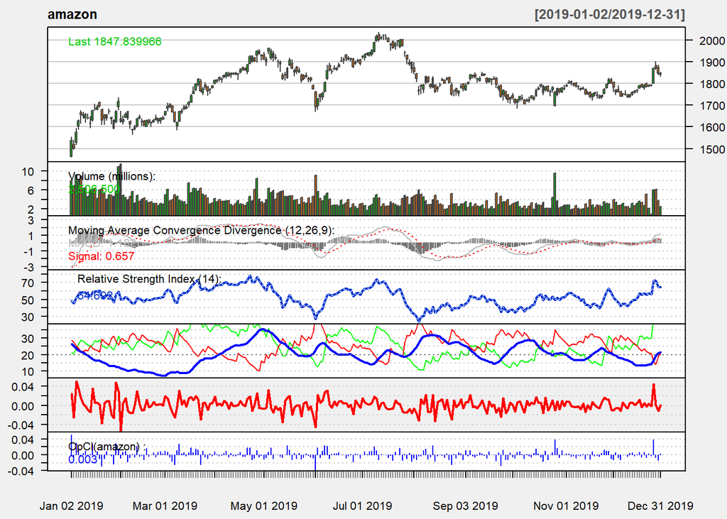

```r
#Strategies for Amazon
options(repr.plot.width = 10, repr.plot.height = 15)
chartSeries(amazon, subset = "2019", theme = "white",
            TA = "addVo();addMACD();addRSI();addADX();addROC();
            addTA(OpCl(amazon), col = 'blue', type = 'h')")
```

There are clear inflection points on the graph where the stock price has dipped which can be potential entry points for someone looking to invest in the stock. In addition we can see that there is a trend of inflection in RSI, and MACD being greater than the signal at these points. In most of these points, DX is above 20 as well. Based on these observations, we identified 4 strategies for trading: * If MACD greater than signal enter and stay in the market (MACD based) * If stock is overbought, enter and stay in the market (MACD and RSI based) * Attempting to time market based on inflection in RSI (returns and RSI based) * If the directional trend is positive, enter the market and stay.

These 4 strategies will be compared agains the buy and hold strategy.

```r
# Strategy 1: if macd>signal, enter and stay in the market.
# If macd<signal, exit the market.
s1_amazon <- ifelse ((amazon_macd$signal < amazon_macd$macd) , 1, 0)
s1_amazon[is.na(s1_amazon)] <-0

# Strategy 2: if overbought, enter and stay in the market.
s2_amazon <- ifelse ((amazon_macd$signal < amazon_macd$macd) & (amazon_rsi$rsi > 70), 1, 0)
s2_amazon[is.na(s2_amazon)] <-0

# Strategy 3: Attempting to time the market by tracking change in RSI, enter and stay in the market
s3_amazon <- ifelse ((amazon_returns$daily > 0 & (amazon_rsi$rsi - stats::lag(amazon_rsi$rsi) > 0)), 1, 0)
s3_amazon[is.na(s3_amazon)] <-0

#Strategy 4: if any of the directional indicators are going up, enter and stay in the market.
s4_amazon <- ifelse((amazon_roc > 0 | amazon_adx$ADX > 20), 1, 0)
s4_amazon[is.na(s4_amazon)] <- 0

# Buy-and-hold: keep it all time. So "1", not "0"
bh_strategy <- rep(1,dim(amazon_returns)[1])

#Backtesting for performance
s1_amazon_performance <- backtest(amazon, amazon_returns$daily, from_date = '2015-01-01', to_date = '2019-12-31',
                              s1_amazon, "Strategy 1 for Amazon")
s2_amazon_performance <- backtest(amazon, amazon_returns$daily, from_date = '2015-01-01', to_date = '2019-12-31',
                                  s2_amazon, "Strategy 2 for Amazon")
s3_amazon_performance <- backtest(amazon, amazon_returns$daily, from_date = '2015-01-01', to_date = '2019-12-31',
                                  s3_amazon, "Strategy 3 for Amazon")
s4_amazon_performance <- backtest(amazon, amazon_returns$daily, from_date = '2015-01-01', to_date = '2019-12-31',
                                  s4_amazon, "Strategy 4 for Amazon")
bh_amazon_performance <- BH_backtest(amazon, amazon_returns$daily, from_date = '2015-01-01', to_date = '2019-12-31',
                                                       "Holding Amazon")

amazon_perf <- data.frame(s1 = s1_amazon_performance$`Strategy 1 for Amazon`,
                          s2 = s2_amazon_performance$`Strategy 2 for Amazon`,
                          s3 = s3_amazon_performance$`Strategy 3 for Amazon`,
                          s4 = s4_amazon_performance$`Strategy 4 for Amazon`,
                          bh = bh_amazon_performance$`Holding Amazon`)
row.names(amazon_perf) <- c('Cumulative Return','Annualized Return',
                    'Sharpe Ratio','Annualized Sharpe Ratio')
amazon_perf
```

|  | s1 | s2 | s3 | s4 | bh |
| --- | --- | --- | --- | --- | --- |
| Cumulative Return | 0.53 | 0.01 | 2.06 | 3.04 | 4.95 |
| Annualized Return | 0.09 | 0.00 | 0.25 | 0.32 | 0.43 |
| Sharpe Ratio | 0.03 | 0.03 | 0.08 | 0.07 | 0.09 |
| Annualized Sharpe Ratio | 0.48 | 0.45 | 1.37 | 1.20 | 1.47 |

Entering the market whenever the directional trend seems positive seems to have the best returns amongst the 4 strategies. However, it is still lower than the buy and hold strategy. Our Attempt to time the market has had the best sharpe ration amongst our strategies yet is lower than buy and hold.

## Analysing Apple on technical indicators and creating strategies

Analysing Apple in a similar fashion

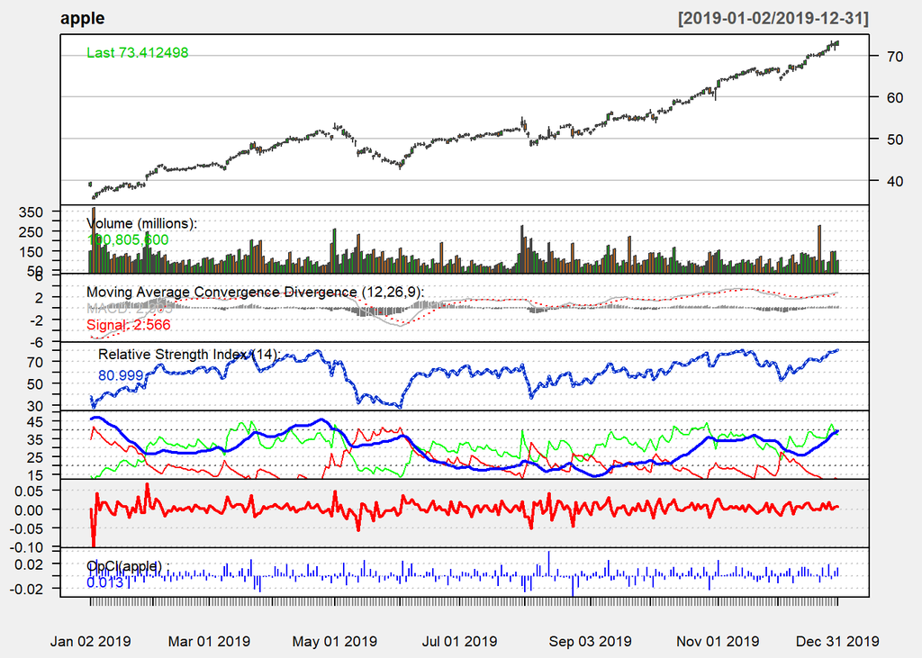

```r
#Strategies for Apple
options(repr.plot.width = 10, repr.plot.height = 15)
chartSeries(apple, subset = "2019", theme = "white",
            TA = "addVo();addMACD();addRSI();addADX();addROC();
            addTA(OpCl(apple), col = 'blue', type = 'h')")
```

While there are fewer obvious inflection points, we similar trends. Therefore we will use the same strategies.

```r
# Strategy 1: if macd>signal, enter and stay in the market.
# If macd<signal, exit the market.
s1_apple <- ifelse ((apple_macd$signal < apple_macd$macd) , 1, 0)
s1_apple[is.na(s1_apple)] <-0

# Strategy 2: if overbought, enter and stay in the market.
s2_apple <- ifelse ((apple_macd$signal < apple_macd$macd) & (apple_rsi$rsi > 70), 1, 0)
s2_apple[is.na(s2_apple)] <-0

# Strategy 3: Attempting to time the market by tracking change in RSI, enter and stay in the market
s3_apple <- ifelse ((apple_returns$daily > 0 & (apple_rsi$rsi - stats::lag(apple_rsi$rsi) > 0)), 1, 0)
s3_apple[is.na(s3_apple)] <-0

#Strategy 4: if any of the directional indicators are going up, enter and stay in the market.
s4_apple <- ifelse((apple_roc > 0 | apple_adx$ADX > 20), 1, 0)
s4_apple[is.na(s4_apple)] <- 0

# Buy-and-hold: keep it all time. So "1", not "0"
bh_apple <- rep(1,dim(apple_returns)[1])

#Backtesting for performance
s1_apple_performance <- backtest(apple, apple_returns$daily, from_date = '2015-01-01', to_date = '2019-12-31',
                                  s1_apple, "Strategy 1 for apple")
s2_apple_performance <- backtest(apple, apple_returns$daily, from_date = '2015-01-01', to_date = '2019-12-31',
                                  s2_apple, "Strategy 2 for apple")
s3_apple_performance <- backtest(apple, apple_returns$daily, from_date = '2015-01-01', to_date = '2019-12-31',
                                  s3_apple, "Strategy 3 for apple")
s4_apple_performance <- backtest(apple, apple_returns$daily, from_date = '2015-01-01', to_date = '2019-12-31',
                                  s4_apple, "Strategy 4 for apple")
bh_apple_performance <- BH_backtest(apple, apple_returns$daily, from_date = '2015-01-01', to_date = '2019-12-31',
                                     "Holding apple")

apple_perf <- data.frame(s1 = s1_apple_performance$`Strategy 1 for apple`,
                          s2 = s2_apple_performance$`Strategy 2 for apple`,
                          s3 = s3_apple_performance$`Strategy 3 for apple`,
                          s4 = s4_apple_performance$`Strategy 4 for apple`,
                          bh = bh_apple_performance$`Holding apple`)
row.names(apple_perf) <- c('Cumulative Return','Annualized Return',
                            'Sharpe Ratio','Annualized Sharpe Ratio')
apple_perf
```

|  | s1 | s2 | s3 | s4 | bh |
| --- | --- | --- | --- | --- | --- |
| Cumulative Return | 0.88 | 0.00 | 1.37 | 1.28 | 1.66 |
| Annualized Return | 0.13 | 0.00 | 0.19 | 0.18 | 0.22 |
| Sharpe Ratio | 0.05 | -0.03 | 0.08 | 0.05 | 0.06 |
| Annualized Sharpe Ratio | 0.81 | -0.45 | 1.33 | 0.78 | 0.87 |

While Apple has performed less impressively in the same period, our strategies have performed similarly. Our market timing strategy has come very close to equally the buy and hold strategy. And is the best strategy on sharpe ratio!

## Analysing Netflix on technical indicators and creating strategies

We will repeat the same analysis and Strategies on Netflix.

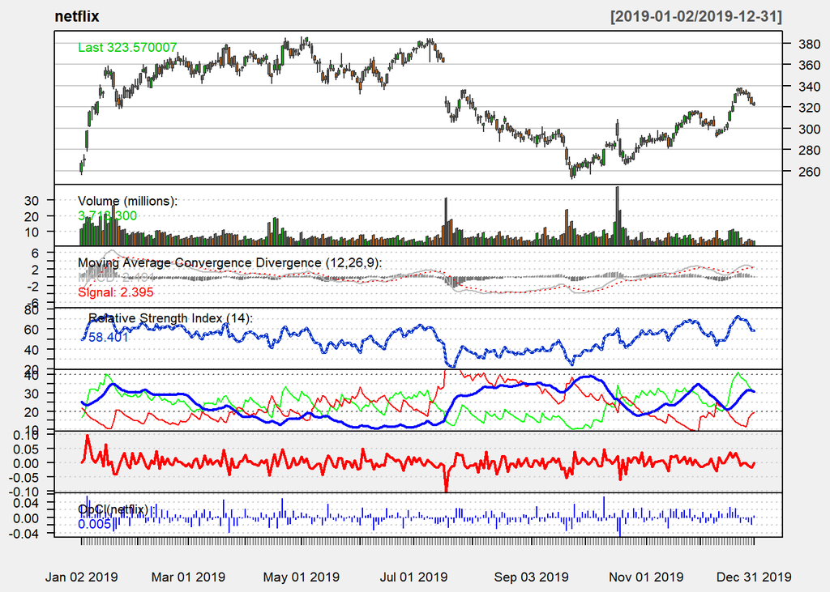

```r
#Strategies for Netflix
options(repr.plot.width = 10, repr.plot.height = 15)
chartSeries(netflix, subset = "2019", theme = "white",
            TA = "addVo();addMACD();addRSI();addADX();addROC();
            addTA(OpCl(netflix), col = 'blue', type = 'h')")
```

Similar trends exists! We will use the same strategy.

```r
# Strategy 1: if macd>signal, enter and stay in the market.
# If macd<signal, exit the market.
s1_netflix <- ifelse ((netflix_macd$signal < netflix_macd$macd) , 1, 0)
s1_netflix[is.na(s1_netflix)] <-0

# Strategy 2: if overbought, enter and stay in the market.
s2_netflix <- ifelse ((netflix_macd$signal < netflix_macd$macd) & (netflix_rsi$rsi > 70), 1, 0)
s2_netflix[is.na(s2_netflix)] <-0

# Strategy 3: Attempting to time the market by tracking change in RSI, enter and stay in the market
s3_netflix <- ifelse ((netflix_returns$daily > 0 & (netflix_rsi$rsi - stats::lag(netflix_rsi$rsi) > 0)), 1, 0)
s3_netflix[is.na(s3_netflix)] <-0

#Strategy 4: if any of the directional indicators are going up, enter and stay in the market.
s4_netflix <- ifelse((netflix_roc > 0 | netflix_adx$ADX > 20), 1, 0)
s4_netflix[is.na(s4_netflix)] <- 0

# Buy-and-hold: keep it all time. So "1", not "0"
bh_netflix <- rep(1,dim(netflix_returns)[1])

#Backtesting for performance
s1_netflix_performance <- backtest(netflix, netflix_returns$daily, from_date = '2015-01-01', to_date = '2019-12-31',
                                 s1_netflix, "Strategy 1 for netflix")
s2_netflix_performance <- backtest(netflix, netflix_returns$daily, from_date = '2015-01-01', to_date = '2019-12-31',
                                 s2_netflix, "Strategy 2 for netflix")
s3_netflix_performance <- backtest(netflix, netflix_returns$daily, from_date = '2015-01-01', to_date = '2019-12-31',
                                 s3_netflix, "Strategy 3 for netflix")
s4_netflix_performance <- backtest(netflix, netflix_returns$daily, from_date = '2015-01-01', to_date = '2019-12-31',
                                 s4_netflix, "Strategy 4 for netflix")
bh_netflix_performance <- BH_backtest(netflix, netflix_returns$daily, from_date = '2015-01-01', to_date = '2019-12-31',
                                    "Holding netflix")

netflix_perf <- data.frame(s1 = s1_netflix_performance$`Strategy 1 for netflix`,
                         s2 = s2_netflix_performance$`Strategy 2 for netflix`,
                         s3 = s3_netflix_performance$`Strategy 3 for netflix`,
                         s4 = s4_netflix_performance$`Strategy 4 for netflix`,
                         bh = bh_netflix_performance$`Holding netflix`)
row.names(netflix_perf) <- c('Cumulative Return','Annualized Return',
                           'Sharpe Ratio','Annualized Sharpe Ratio')
netflix_perf
```

|  | s1 | s2 | s3 | s4 | bh |
| --- | --- | --- | --- | --- | --- |
| Cumulative Return | 2.04 | -0.01 | 0.18 | 3.97 | 5.63 |
| Annualized Return | 0.25 | 0.00 | 0.03 | 0.38 | 0.46 |
| Sharpe Ratio | 0.06 | -0.03 | 0.02 | 0.07 | 0.07 |
| Annualized Sharpe Ratio | 0.83 | -0.45 | 0.15 | 1.03 | 1.11 |

Curiously, Our market timing strategy has performed pretty badly for netflix. However, directional trading has done remarkably well. However, buy and hold is still the best strategy.

## Analysing over different time periods

Buy and hold has shown to be the best strategy for long term trading. However, let us test our best strategies against buy and hold for different time periods.

### Returns over 1 month

```r
s4_amazon_performance_1 <-  backtest(amazon, amazon_returns$daily, from_date = '2019-01-01', to_date =
                                       '2019-02-01', s4_amazon, "Amazon 1 month")
bh_amazon_performance_1 <- BH_backtest(amazon, amazon_returns$daily, from_date = '2019-01-01', to_date =
                                       '2019-02-01', "Holding amazon for 1 month")
s3_apple_performance_1 <-  backtest(apple, apple_returns$daily,from_date = '2019-01-01', to_date =
                                       '2019-02-01', s3_apple, "apple 1 month")
bh_apple_performance_1 <- BH_backtest(apple, apple_returns$daily, from_date = '2019-01-01', to_date =
                                       '2019-02-01', "Holding apple for 1 month")
s4_netflix_performance_1 <-  backtest(netflix, netflix_returns$daily, from_date = '2019-01-01', to_date =
                                       '2019-02-01', s4_netflix, "netflix 1 month")
bh_netflix_performance_1 <- BH_backtest(netflix, netflix_returns$daily, from_date = '2019-01-01',
                                        to_date='2019-02-01', "Holding netflix for 1 month")

month_perf <- data.frame(s4_amazon = s4_amazon_performance_1$`Amazon 1 month`,
                         bh_amazon = bh_amazon_performance_1$`Holding amazon for 1 month`,
                         s3_apple = s3_apple_performance_1$`apple 1 month`,
                         bh_apple = bh_apple_performance_1$`Holding apple for 1 month`,
                         s4_netflix = s4_netflix_performance_1$`netflix 1 month`,
                         bh_netflix = bh_netflix_performance_1$`Holding netflix for 1 month`)
row.names(month_perf) <- c('Cumulative Return','Annualized Return',
                           'Sharpe Ratio','Annualized Sharpe Ratio')
month_perf
```

|  | s4_amazon | bh_amazon | s3_apple | bh_apple | s4_netflix | bh_netflix |
| --- | --- | --- | --- | --- | --- | --- |
| Cumulative Return | 0.05 | 0.08 | 0.00 | 0.06 | 0.27 | 0.27 |
| Annualized Return | 0.67 | 1.49 | -0.05 | 0.86 | 14.41 | 14.41 |
| Sharpe Ratio | 0.09 | 0.15 | -0.03 | 0.10 | 0.34 | 0.34 |
| Annualized Sharpe Ratio | 1.62 | 3.47 | -0.46 | 1.76 | 27.16 | 27.16 |

```r
s4_amazon_performance_3 <-  backtest(amazon, amazon_returns$daily, from_date = '2019-01-01', to_date =
                                       '2019-05-01', s4_amazon, "Amazon 1 month")
bh_amazon_performance_3 <- BH_backtest(amazon, amazon_returns$daily, from_date = '2019-01-01', to_date =
                                       '2019-05-01', "Holding amazon for 1 month")
s3_apple_performance_3 <-  backtest(apple, apple_returns$daily,from_date = '2019-01-01', to_date =
                                       '2019-05-01', s3_apple, "apple 1 month")
bh_apple_performance_3 <- BH_backtest(apple, apple_returns$daily, from_date = '2019-01-01', to_date =
                                       '2019-05-01', "Holding apple for 1 month")
s4_netflix_performance_3 <-  backtest(netflix, netflix_returns$daily, from_date = '2019-01-01', to_date =
                                       '2019-05-01', s4_netflix, "netflix 1 month")
bh_netflix_performance_3 <- BH_backtest(netflix, netflix_returns$daily, from_date = '2019-01-01',
                                        to_date='2019-05-01', "Holding netflix for 1 month")

quarter_perf <- data.frame(s4_amazon = s4_amazon_performance_3$`Amazon 1 month`,
                         bh_amazon = bh_amazon_performance_3$`Holding amazon for 1 month`,
                         s3_apple = s3_apple_performance_3$`apple 1 month`,
                         bh_apple = bh_apple_performance_3$`Holding apple for 1 month`,
                         s4_netflix = s4_netflix_performance_3$`netflix 1 month`,
                         bh_netflix = bh_netflix_performance_3$`Holding netflix for 1 month`)
row.names(quarter_perf) <- c('Cumulative Return','Annualized Return',
                           'Sharpe Ratio','Annualized Sharpe Ratio')
quarter_perf
```

|  | s4_amazon | bh_amazon | s3_apple | bh_apple | s4_netflix | bh_netflix |
| --- | --- | --- | --- | --- | --- | --- |
| Cumulative Return | 0.17 | 0.27 | 0.11 | 0.33 | 0.28 | 0.42 |
| Annualized Return | 0.61 | 1.08 | 0.39 | 1.40 | 1.14 | 1.87 |
| Sharpe Ratio | 0.13 | 0.18 | 0.16 | 0.19 | 0.14 | 0.19 |
| Annualized Sharpe Ratio | 2.43 | 3.97 | 2.89 | 4.66 | 3.14 | 4.97 |

### Returns over 1 year

```r
s4_amazon_performance_12 <-  backtest(amazon, amazon_returns$daily, from_date = '2019-01-01', to_date =
                                       '2020-01-01', s4_amazon, "Amazon 1 month")
bh_amazon_performance_12 <- BH_backtest(amazon, amazon_returns$daily, from_date = '2019-01-01', to_date =
                                       '2020-01-01', "Holding amazon for 1 month")
s3_apple_performance_12 <-  backtest(apple, apple_returns$daily,from_date = '2019-01-01', to_date =
                                       '2020-01-01', s3_apple, "apple 1 month")
bh_apple_performance_12 <- BH_backtest(apple, apple_returns$daily, from_date = '2019-01-01', to_date =
                                       '2020-01-01', "Holding apple for 1 month")
s4_netflix_performance_12 <-  backtest(netflix, netflix_returns$daily, from_date = '2019-01-01', to_date =
                                       '2020-01-01', s4_netflix, "netflix 1 month")
bh_netflix_performance_12 <- BH_backtest(netflix, netflix_returns$daily, from_date = '2019-01-01',
                                        to_date='2020-01-01', "Holding netflix for 1 month")

year_perf <- data.frame(s4_amazon = s4_amazon_performance_12$`Amazon 1 month`,
                         bh_amazon = bh_amazon_performance_12$`Holding amazon for 1 month`,
                         s3_apple = s3_apple_performance_12$`apple 1 month`,
                         bh_apple = bh_apple_performance_12$`Holding apple for 1 month`,
                         s4_netflix = s4_netflix_performance_12$`netflix 1 month`,
                         bh_netflix = bh_netflix_performance_12$`Holding netflix for 1 month`)
row.names(year_perf) <- c('Cumulative Return','Annualized Return',
                           'Sharpe Ratio','Annualized Sharpe Ratio')
year_perf
```

|  | s4_amazon | bh_amazon | s3_apple | bh_apple | s4_netflix | bh_netflix |
| --- | --- | --- | --- | --- | --- | --- |
| Cumulative Return | 0.10 | 0.23 | 0.36 | 0.86 | 0.25 | 0.21 |
| Annualized Return | 0.10 | 0.23 | 0.36 | 0.86 | 0.25 | 0.21 |
| Sharpe Ratio | 0.04 | 0.06 | 0.15 | 0.16 | 0.06 | 0.05 |
| Annualized Sharpe Ratio | 0.50 | 1.01 | 2.74 | 3.29 | 0.84 | 0.60 |

While buy and hold seems to have performed better for Amazon and Apple durng a year, Our strategy has performed better than buy and hold for Netflix.

## Attempting to create a machine-learning model

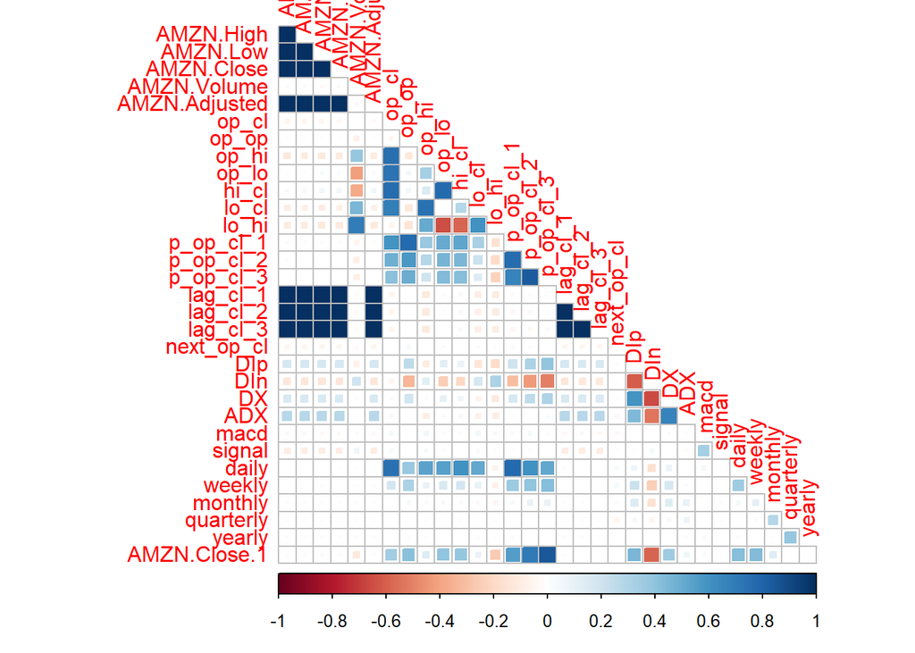

```r
#joining all variables and factors into a single object and creating test and train data

model_amazon <- xts::merge.xts(amazon, amazon_adx, amazon_macd, amazon_returns, amazon_roc, join = "left")
train_amazon <- model_amazon[index(model_amazon) >= '2010-01-01' & index(model_amazon) <= '2018-12-31']
test_amazon <- model_amazon[index(model_amazon) >= '2019-01-01' & index(model_amazon) <= '2019-12-31']
train_amazon[is.na(train_amazon)] <- 0
test_amazon[is.na(test_amazon)] <- 0

#testing for correlation
corrplot(cor(train_amazon), method = "square", type = "lower", diag = F)
```

Interestingly, there is very little correlation between the next day’s open to close with any of the day’s factors. However, we are dropping the following variables since there is high correlation:

- Prices: High, Low and Close, Close1
- Differences: op_cl, lo_hi
- Percentages: p_op_cl_3
- lags: Lag_cl_2, lag_cl_3
- Indicators: DIn
- Returns: Daily

```r
#creating a new column for buy or sell strategy
#We want to buy today, if prices go up tomorrow. i.e. next_op_cl > 0
train_amazon$target <- ifelse(train_amazon$next_op_cl > 0, 1, 0)
test_amazon$target <- ifelse(test_amazon$next_op_cl > 0, 1, 0)

drop_cols <-  c("AMZN.High", "AMZN.Low", "AMZN.Close", "AMZN.Close.1", "op_cl", "lo_hi", "p_op_cl_3",
                "lag_cl_2", "lag_cl_3", "DIn", "daily", "next_op_cl")
train_amazon <- train_amazon[, !colnames(train_amazon) %in% drop_cols]
test_amazon <- test_amazon[, !colnames(test_amazon) %in% drop_cols]

#Using a boosting model
set.seed(257)
trControl=trainControl(method="cv",number=10)
tuneGrid=  expand.grid(n.trees = 100, interaction.depth = c(1,2),
                       shrinkage = (1:100)*0.001,n.minobsinnode=5)
garbage <- capture.output(cvBoost <- train(target~.,data=train_amazon,method="gbm",
                trControl=trControl, tuneGrid=tuneGrid))
boostCV = gbm(target~.,data=train_amazon,distribution="gaussian",
              n.trees=cvBoost$bestTune$n.trees,
              interaction.depth=cvBoost$bestTune$interaction.depth,
              shrinkage=cvBoost$bestTune$shrinkage,
              n.minobsinnode = cvBoost$bestTune$n.minobsinnode)
predBoostCV = predict(boostCV,test_amazon,n.trees=1000)
rmseBoostCV = sqrt(mean((predBoostCV-test_amazon$target)^2));
sprintf("The RMSE in test data for the model is %f", rmseBoostCV)
```

```
## [1] "The RMSE in test data for the model is 0.499920"
```

Let us use a cut_off of 0.5 for calculating investment decisions.

```r
test_amazon$prediction <- ifelse(predBoostCV > 0.5, 1, 0)

#Model strategy
sm_amazon <- ifelse ((test_amazon$prediction == 1) , 1, 0)
sm_amazon[is.na(sm_amazon)] <-0

#Checking Performance
sm_amazon_perf <- backtest(amazon, amazon_returns$daily, from_date = '2019-01-01', to_date = '2019-12-31',
                                  sm_amazon, "Model strategy for Amazon")
bh_amazon_perf <- BH_backtest(amazon, amazon_returns$daily, from_date = '2019-01-01', to_date = '2019-12-31',
                                                       "Holding Amazon")

amazon_perf2 <- data.frame(Model = sm_amazon_perf$`Model strategy for Amazon`,
                          BuyHold = bh_amazon_perf$`Holding Amazon`)
row.names(amazon_perf2) <- c('Cumulative Return','Annualized Return',
                    'Sharpe Ratio','Annualized Sharpe Ratio')
amazon_perf2
```

|  | Model | BuyHold |
| --- | --- | --- |
| Cumulative Return | 0.27 | 0.23 |
| Annualized Return | 0.27 | 0.23 |
| Sharpe Ratio | 0.08 | 0.06 |
| Annualized Sharpe Ratio | 1.39 | 1.01 |

Interestingly, our machine learning model has performed marginally better than buy and hold for a one year period. This is definitely worth further examination.